# Tools Comparison (Detailed): Codex CLI + Codex GPT-5.3

## Run Metadata

- Harness: `codex-cli`
- Model: `codex-gpt-5-3`
- Prompt type: `detailed`

## Setup

```r
library(dplyr)
library(ggplot2)
library(readr)
library(stringr)
library(forcats)
library(tidyr)
library(purrr)
library(broom)
library(MASS)

df_raw <- read_csv(here::here("data/synthetic/simulated_maternal_health_data.csv"), show_col_types = FALSE)
```

## Prompt

```
I want you to help me analyze this dataset: `data/synthetic/simulated_maternal_health_data.csv`

My goal is to produce a thorough analysis that is statistically sound and lays out all steps of the analysis.

Please do the following:

1. Load the dataset and normalize columns/types.
   - Use clear snake_case names.
   - Ensure categorical vs numeric types are explicit.

2. Summarize the data.
   - Report row count, column count, missingness, and key descriptive summaries.
   - Flag suspicious values or quality concerns.

3. Create key visualizations.
   - Show relationships for:
     - `received_comprehensive_postnatal_care`
     - `distance_to_provider`
     - `insurance`
     - `race_ethnicity`

4. Build a count outcome and model it.
   - Define `comorbidity_count` as the row-wise sum of:
     - `obesity`,
     - `multiple_gestation`,
     - `diabetes`,
     - `heart_disease`,
     - `placenta_previa`,
     - `hypertension`,
     - `gest_hypertension`,
     - `preeclampsia`.
   - Select an appropriate count-model strategy (Poisson vs negative binomial, with justification).
   - Fit the model and report interpretable results.

5. Report results responsibly.
   - Do not overstate causality.
   - Include model assumptions, diagnostics, and limitations.

Constraints:
- Prefer readable, modular, reproducible code that follows R community idioms.
- Report back a summary of what you changed.
```

## 1) Normalize Columns and Types

```r
binary_cols <- c(
  "received_comprehensive_postnatal_care",
  "obesity",
  "multiple_gestation",
  "diabetes",
  "heart_disease",
  "placenta_previa",
  "hypertension",
  "gest_hypertension",
  "preeclampsia"
)

factor_cols <- c("state", "edu", "race_ethnicity", "insurance", "job_type", "self_report_income")

df <- df_raw %>%
  rename_with(~ str_replace_all(.x, "[^A-Za-z0-9]+", "_")) %>%
  rename_with(~ str_to_lower(.x)) %>%
  mutate(
    across(all_of(factor_cols), as.factor),
    self_report_income = fct_relevel(
      self_report_income,
      "$0–$24,999",
      "$25,000–$49,999",
      "$50,000–$74,999",
      "$75,000–$99,999",
      "$100,000+"
    ),
    across(all_of(binary_cols), ~ as.integer(.x))
  )
glimpse(df)
```

```
Rows: 50,000
Columns: 20
$ id                                    <dbl> 1, 2, 3, 4, 5, 6, 7, 8, 9, 10, 1…
$ provider_id                           <dbl> 1, 1, 1, 1, 1, 1, 1, 1, 1, 1, 1,…
$ state                                 <fct> AK, AK, AK, AK, AK, AK, AK, AK, …
$ received_comprehensive_postnatal_care <int> 0, 1, 0, 0, 0, 1, 1, 1, 0, 0, 0,…
$ self_report_income                    <fct> "$50,000–$74,999", "$50,000–$74,…
$ age                                   <dbl> 31, 26, 33, 37, 21, 33, 25, 34, …
$ edu                                   <fct> hs, hs, some_college, hs, hs, hs…
$ race_ethnicity                        <fct> white, white, white, asian, aian…
$ insurance                             <fct> no_insurance, no_insurance, no_i…
$ job_type                              <fct> unskilled, unskilled, unskilled,…
$ dependents                            <dbl> 2, 2, 2, 2, 2, 2, 2, 3, 3, 3, 3,…
$ distance_to_provider                  <dbl> 1.7889754, 10.8991396, 35.122047…
$ obesity                               <int> 0, 0, 1, 0, 1, 1, 1, 1, 1, 1, 0,…
$ multiple_gestation                    <int> 0, 0, 0, 0, 0, 1, 0, 1, 0, 0, 0,…
$ diabetes                              <int> 0, 0, 0, 0, 0, 0, 0, 0, 0, 0, 0,…
$ heart_disease                         <int> 0, 0, 0, 1, 0, 0, 1, 0, 0, 0, 0,…
$ placenta_previa                       <int> 0, 0, 0, 0, 0, 0, 0, 0, 0, 0, 0,…
$ hypertension                          <int> 0, 0, 1, 0, 0, 1, 0, 0, 0, 0, 0,…
$ gest_hypertension                     <int> 0, 0, 0, 0, 0, 0, 0, 0, 0, 0, 0,…
$ preeclampsia                          <int> 0, 0, 0, 0, 0, 0, 0, 0, 0, 0, 0,…
```

## 2) Data Summary and Quality Checks

```r
n_rows <- nrow(df)
n_cols <- ncol(df)

missing_summary <- df %>%
  summarise(across(everything(), ~ sum(is.na(.x)))) %>%
  pivot_longer(everything(), names_to = "column", values_to = "missing_n") %>%
  mutate(missing_pct = missing_n / n_rows)

list(
  row_count = n_rows,
  column_count = n_cols,
  total_missing = sum(missing_summary$missing_n)
)
```

```
$row_count
[1] 50000

$column_count
[1] 20

$total_missing
[1] 0
```

```r
missing_summary %>% arrange(desc(missing_n)) %>% print(n = n_cols)
```

```
# A tibble: 20 × 3
   column                                missing_n missing_pct
   <chr>                                     <int>       <dbl>
 1 id                                            0           0
 2 provider_id                                   0           0
 3 state                                         0           0
 4 received_comprehensive_postnatal_care         0           0
 5 self_report_income                            0           0
 6 age                                           0           0
 7 edu                                           0           0
 8 race_ethnicity                                0           0
 9 insurance                                     0           0
10 job_type                                      0           0
11 dependents                                    0           0
12 distance_to_provider                          0           0
13 obesity                                       0           0
14 multiple_gestation                            0           0
15 diabetes                                      0           0
16 heart_disease                                 0           0
17 placenta_previa                               0           0
18 hypertension                                  0           0
19 gest_hypertension                             0           0
20 preeclampsia                                  0           0
```

```r
numeric_summary <- df %>%
  dplyr::select(where(is.numeric)) %>%
  summarise(across(
    everything(),
    list(
      mean = ~ mean(.x, na.rm = TRUE),
      sd = ~ sd(.x, na.rm = TRUE),
      p25 = ~ quantile(.x, 0.25, na.rm = TRUE),
      median = ~ median(.x, na.rm = TRUE),
      p75 = ~ quantile(.x, 0.75, na.rm = TRUE)
    )
  )) %>%
  pivot_longer(everything(), names_to = c("variable", ".value"), names_sep = "_")
categorical_summary <- df %>%
  dplyr::select(where(is.factor)) %>%
  pivot_longer(everything(), names_to = "variable", values_to = "level") %>%
  count(variable, level, sort = TRUE) %>%
  group_by(variable) %>%
  mutate(prop = n / sum(n)) %>%
  ungroup()

numeric_summary
```

[output not shown]

```r
categorical_summary %>% print(n = 60)
```

```
# A tibble: 78 × 4
   variable           level                 n    prop
   <chr>              <fct>             <int>   <dbl>
 1 race_ethnicity     white             31511 0.630
 2 job_type           unskilled         27192 0.544
 3 edu                hs                23108 0.462
 4 self_report_income $50,000–$74,999   21279 0.426
 5 insurance          no_insurance      20810 0.416
 6 insurance          private           17908 0.358
 7 edu                some_college      14959 0.299
 8 self_report_income $25,000–$49,999   14710 0.294
 9 job_type           professional      14293 0.286
10 insurance          state_provided    11282 0.226
11 self_report_income $75,000–$99,999    9784 0.196
12 race_ethnicity     hispanic           8792 0.176
```

[output cut: 49 more lines]

```r
binary_violations <- map_dfr(binary_cols, function(col_nm) {
  bad_n <- df %>% filter(!(.data[[col_nm]] %in% c(0L, 1L) | is.na(.data[[col_nm]]))) %>% nrow()
  tibble(variable = col_nm, bad_values = bad_n)
})

quality_flags <- tibble(
  check = c(
    "duplicate id rows",
    "age outside [12, 55]",
    "negative distance_to_provider",
    "distance_to_provider > 200"
  ),
  flagged_n = c(
    sum(duplicated(df$id)),
    sum(df$age < 12 | df$age > 55, na.rm = TRUE),
    sum(df$distance_to_provider < 0, na.rm = TRUE),
    sum(df$distance_to_provider > 200, na.rm = TRUE)
  )
)

binary_violations
```

```
# A tibble: 9 × 2
  variable                              bad_values
  <chr>                                      <int>
1 received_comprehensive_postnatal_care          0
2 obesity                                        0
3 multiple_gestation                             0
4 diabetes                                       0
5 heart_disease                                  0
6 placenta_previa                                0
7 hypertension                                   0
8 gest_hypertension                              0
9 preeclampsia                                   0
```

```r
quality_flags
```

```
# A tibble: 4 × 2
  check                         flagged_n
  <chr>                             <int>
1 duplicate id rows                     0
2 age outside [12, 55]                  0
3 negative distance_to_provider         0
4 distance_to_provider > 200            0
```

## 3) Key Visualizations

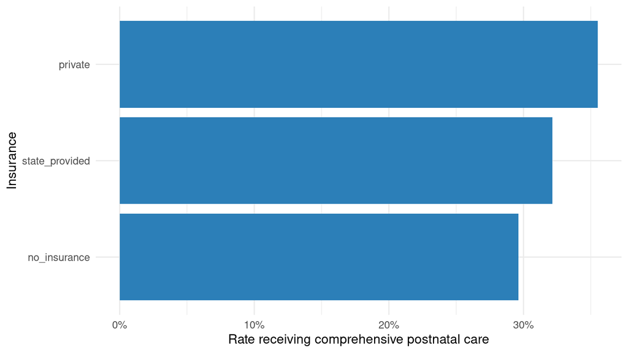

Comprehensive postnatal care rates by insurance type

```r
df %>%
  group_by(insurance) %>%
  summarise(care_rate = mean(received_comprehensive_postnatal_care, na.rm = TRUE), .groups = "drop") %>%
  ggplot(aes(x = fct_reorder(insurance, care_rate), y = care_rate)) +
  geom_col(fill = "#2C7FB8") +
  scale_y_continuous(labels = scales::percent_format()) +
  coord_flip() +
  labs(x = "Insurance", y = "Rate receiving comprehensive postnatal care") +
  theme_minimal(base_size = 12)
```

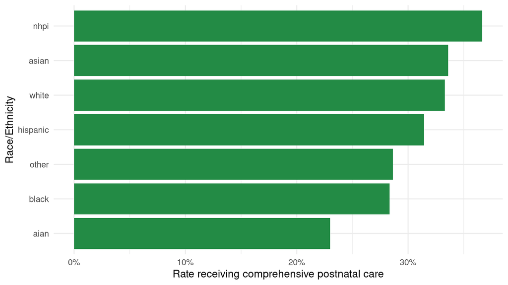

Comprehensive postnatal care rates by race/ethnicity

```r
df %>%
  group_by(race_ethnicity) %>%
  summarise(care_rate = mean(received_comprehensive_postnatal_care, na.rm = TRUE), .groups = "drop") %>%
  ggplot(aes(x = fct_reorder(race_ethnicity, care_rate), y = care_rate)) +
  geom_col(fill = "#238B45") +
  scale_y_continuous(labels = scales::percent_format()) +
  coord_flip() +
  labs(x = "Race/Ethnicity", y = "Rate receiving comprehensive postnatal care") +
  theme_minimal(base_size = 12)
```

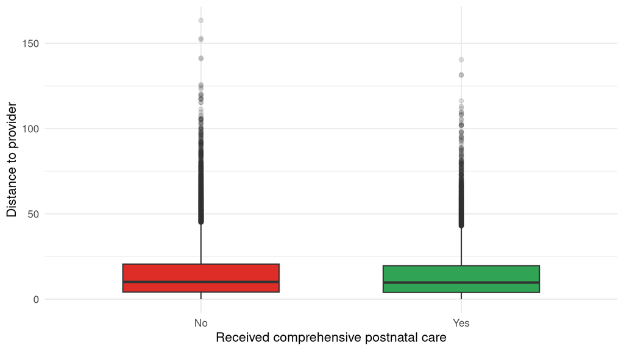

Distance to provider by postnatal care status

```r
df %>%
  mutate(care_status = factor(received_comprehensive_postnatal_care, levels = c(0, 1), labels = c("No", "Yes"))) %>%
  ggplot(aes(x = care_status, y = distance_to_provider, fill = care_status)) +
  geom_boxplot(outlier.alpha = 0.15, width = 0.6) +
  scale_fill_manual(values = c("#DE2D26", "#31A354")) +
  labs(x = "Received comprehensive postnatal care", y = "Distance to provider") +
  theme_minimal(base_size = 12) +
  theme(legend.position = "none")
```

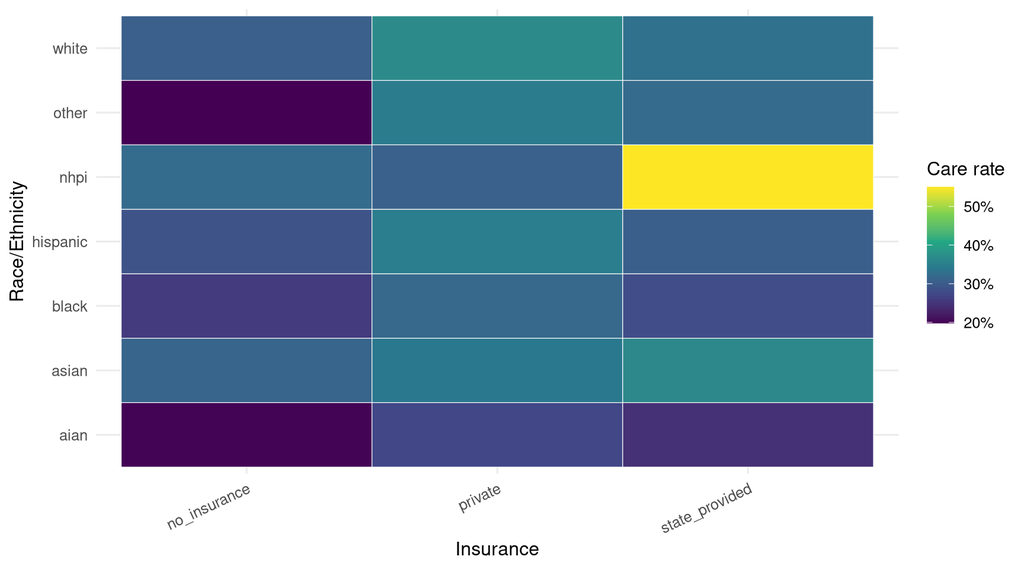

Care rates by race/ethnicity and insurance

```r
df %>%
  group_by(race_ethnicity, insurance) %>%
  summarise(care_rate = mean(received_comprehensive_postnatal_care, na.rm = TRUE), .groups = "drop") %>%
  ggplot(aes(x = insurance, y = race_ethnicity, fill = care_rate)) +
  geom_tile(color = "white", linewidth = 0.2) +
  scale_fill_viridis_c(labels = scales::percent_format()) +
  labs(x = "Insurance", y = "Race/Ethnicity", fill = "Care rate") +
  theme_minimal(base_size = 12) +
  theme(axis.text.x = element_text(angle = 25, hjust = 1))
```

## 4) Count Outcome and Model Selection

```r
comorbidity_vars <- c(
  "obesity",
  "multiple_gestation",
  "diabetes",
  "heart_disease",
  "placenta_previa",
  "hypertension",
  "gest_hypertension",
  "preeclampsia"
)

df_model <- df %>%
  mutate(
    comorbidity_count = rowSums(across(all_of(comorbidity_vars)), na.rm = TRUE),
    care_status = factor(received_comprehensive_postnatal_care, levels = c(0, 1), labels = c("No", "Yes"))
  )

df_model %>%
  count(comorbidity_count) %>%
  mutate(prop = n / sum(n))
```

```
# A tibble: 8 × 3
  comorbidity_count     n    prop
              <dbl> <int>   <dbl>
1                 0 21350 0.427
2                 1 16560 0.331
3                 2  8359 0.167
4                 3  2873 0.0575
5                 4   706 0.0141
6                 5   134 0.00268
7                 6    17 0.00034
8                 7     1 0.00002
```

```r
model_formula <- comorbidity_count ~ care_status + distance_to_provider + insurance + race_ethnicity + age + dependents

poisson_fit <- glm(model_formula, data = df_model, family = poisson(link = "log"))
nb_fit <- MASS::glm.nb(model_formula, data = df_model)

poisson_dispersion <- sum(residuals(poisson_fit, type = "pearson")^2) / poisson_fit$df.residual
model_compare <- tibble(
  model = c("Poisson", "Negative binomial"),
  aic = c(AIC(poisson_fit), AIC(nb_fit))
)

chosen_model <- if (poisson_dispersion > 1.2 && AIC(nb_fit) + 2 < AIC(poisson_fit)) nb_fit else poisson_fit
chosen_model_name <- if (identical(chosen_model, nb_fit)) "Negative binomial" else "Poisson"

list(
  poisson_dispersion_ratio = poisson_dispersion,
  model_aic = model_compare,
  selected_model = chosen_model_name
)
```

```
$poisson_dispersion_ratio
[1] 1.085522

$model_aic
# A tibble: 2 × 2
  model                 aic
  <chr>               <dbl>
1 Poisson           127029.
2 Negative binomial 126858.

$selected_model
[1] "Poisson"
```

```r
coef_table <- tidy(chosen_model, conf.int = TRUE, exponentiate = TRUE) %>%
  mutate(across(c(estimate, conf.low, conf.high), round, 3)) %>%
  rename(irr = estimate, irr_low = conf.low, irr_high = conf.high)
coef_table %>%
  dplyr::select(term, irr, irr_low, irr_high, p.value) %>%
  arrange(p.value)
```

```
# A tibble: 13 × 5
   term                      irr irr_low irr_high  p.value
   <chr>                   <dbl>   <dbl>    <dbl>    <dbl>
 1 age                     1.02    1.01     1.02  1.02e-94
 2 (Intercept)             0.562   0.499    0.63  1.89e-22
 3 care_statusYes          1.04    1.02     1.06  1.48e- 4
 4 insurancestate_provided 0.972   0.948    0.996 2.24e- 2
 5 insuranceprivate        0.98    0.959    1.00  7.22e- 2
 6 race_ethnicityother     1.14    0.976    1.34  9.50e- 2
 7 dependents              0.994   0.983    1.00  2.16e- 1
 8 race_ethnicityblack     1.06    0.949    1.18  3.21e- 1
 9 race_ethnicitywhite     1.05    0.941    1.17  4.15e- 1
10 distance_to_provider    1       0.999    1     4.95e- 1
11 race_ethnicityhispanic  1.03    0.925    1.15  5.94e- 1
12 race_ethnicitynhpi      0.966   0.748    1.23  7.87e- 1
13 race_ethnicityasian     0.998   0.892    1.12  9.70e- 1
```

### Interpretation notes

- Coefficients are reported as incidence rate ratios (IRRs): values above 1 indicate higher expected comorbidity count, while values below 1 indicate lower expected count, conditional on other included covariates.
- Because this is observational synthetic data, these associations should be interpreted as descriptive/associational, not causal.

## 5) Assumptions, Diagnostics, and Limitations

```r
df_model <- df_model %>%
  mutate(
    fitted_mean = fitted(chosen_model),
    pearson_resid = residuals(chosen_model, type = "pearson"),
    deviance_resid = residuals(chosen_model, type = "deviance")
  )

obs_zero_rate <- mean(df_model$comorbidity_count == 0)
pred_zero_rate <- mean(if (chosen_model_name == "Poisson") {
  dpois(0, lambda = df_model$fitted_mean)
} else {
  theta <- chosen_model$theta
  (theta / (theta + df_model$fitted_mean))^theta
})

tibble(
  metric = c("Observed zero rate", "Predicted zero rate"),
  value = c(obs_zero_rate, pred_zero_rate)
)
```

```
# A tibble: 2 × 2
  metric              value
  <chr>               <dbl>
1 Observed zero rate  0.427
2 Predicted zero rate 0.404
```

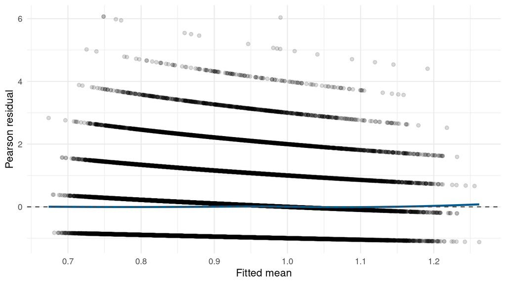

Pearson residuals vs fitted mean

```r
df_model %>%
  ggplot(aes(x = fitted_mean, y = pearson_resid)) +
  geom_point(alpha = 0.15) +
  geom_smooth(method = "loess", se = FALSE, color = "#045A8D") +
  geom_hline(yintercept = 0, linetype = "dashed", color = "#444444") +
  labs(x = "Fitted mean", y = "Pearson residual") +
  theme_minimal(base_size = 12)
```

### Model assumptions and practical limits

- Mean-variance structure: Poisson assumes equality of mean and variance; negative binomial relaxes this with an overdispersion parameter. The model choice above uses both dispersion and AIC.
- Independence: records are assumed conditionally independent; clustering by provider/state could violate this and may require multilevel models.
- Functional form: continuous predictors are modeled linearly on the log scale; nonlinear effects were not explicitly modeled.
- Omitted variables: unmeasured confounding and selection mechanisms can bias associations.
- Outcome definition: `comorbidity_count` is a constructed summary and does not reflect severity weighting across conditions.

## Summary of What Changed

- Loaded and type-normalized the dataset with explicit factor/numeric/binary handling.
- Reported row/column counts, complete missingness profile, descriptive summaries, and data-quality checks.
- Added targeted visualizations connecting postnatal care with distance, insurance, and race/ethnicity (including a race-insurance heatmap).
- Created `comorbidity_count` exactly as specified and fit both Poisson and negative binomial candidates.
- Selected the count model based on dispersion and AIC, then reported exponentiated IRRs with confidence intervals.
- Added diagnostics (zero-rate check, residual-vs-fitted plot) plus non-causal interpretation and limitations.